# Advanced Data Analyis HW7

Poisson and Negative Binomial regression

Bing-Jie Yen bj.yen@wustl.edu

March 22nd, 2018

For this week’s homework, we will again be using the 2016 BRFSS data. The dataset link is here: Our motivating question for this week’s exercise is what are the predictors of marijuana and hasish use rates. We will use the BRFSS data from Colorado citizens since they may be more likely to accurately report their marijuana or hasish use because marijuana is legal in that state. The question regarding marijuana or hasish use is as follows: “During the past 30 days, on how many days did you use marijuana or hasish?” The responses are coded as follows:

- 1-30 Number of days
- 88 None
- 77 Don’t know/Not Sure
- 99 Refused
- Blank Not asked or missing

The dataset includes 14,958 observations and is not a sample of the BRFSS data like previously but includes all respondents from Colorado. Of note, this is not ideal data for this type of problem because there are a lot of 0’s in the data (people who didn’t use any marijuana or hashish in the last 30 days); however, the dataset is sufficient to illustrate the major key points for Poisson and Negative Binomial regression. Ideally, these data might be modeled using zero inflated negative binomial or hurdle regression which is beyond the scope of this course. A reading suggestion is provided however at the end for those who want to know more and it also may be helpful someday when you are faced with this problem in your professional careers.

# Read in data and load libraries

Import the data from the Github website (BRFSS.2016.co.xlsx) and load these libraries:MASS, lmtest, stargazer, sandwich, margins, readxl, ggplot2, and tidyverse for this homework.

```r
library(ggplot2)
library(reshape2)
library(plotly)
library(readxl)
library(RColorBrewer)
library(plyr)
library(ggfortify)
library(foreign)
library(Hmisc)
library(memisc)
library(margins)
library(sandwich)
library(lmtest)
library(MASS)
# I change the directory to my gihub link because I somehow have difficulty to read 'xlsx' in Windows.
BRFSS.CO<-'https://raw.githubusercontent.com/bjyen/2018-Advanced-Data-Analysis/master/BRFSS.2016.CO.csv'
BRFSS.CO<-read.csv(BRFSS.CO)
BRFSS.CO<-as.data.frame(BRFSS.CO)
```

# Recode

- Recode values for `MARIJANA`=88 to 0’s and make a complete dataset by excluding individuals with values for `MARIJANA` of “NA”, 77, and 99, and recode `MARIJANA` as an integer using the as.integer function.
- Recode values for `sex` of 0 for female and 1 for male
- Recode `income` as 3=“Refused” and “Don’t know/Not Sure”, 2 as between <$10K-<25K, 1 as 25K-50K and 0 as >=50K.

```r
# MARIJANA
BRFSS.CO$MARIJANA[BRFSS.CO$MARIJANA==88]<-NA
BRFSS.CO<-BRFSS.CO[!(BRFSS.CO$MARIJANA==77 | BRFSS.CO$MARIJANA==99),]
BRFSS.CO[complete.cases(BRFSS.CO$MARIJANA,BRFSS.CO$sex),]
```

|  | ID | MARIJANA | employed | income | seatbelt | diabetes | diabetes_short_label | sex | height | weight | bmi | age |
| --- | --- | --- | --- | --- | --- | --- | --- | --- | --- | --- | --- | --- |
| 140 | 140 | 30 | Employed for wages | $50,000 to less than $75,000 | Always | No | No | Female | 1.63 | 68.04 | 25.75 | 33 |
| 145 | 145 | 25 | Self-employed | $75,000 or more | Always | No | No | Male | 1.80 | 74.84 | 23.01 | 66 |
| 181 | 181 | 16 | Unable to work | $25,000 to less than $35,000 | Seldom | No, pre-diabetes or borderline diabetes | pre/borderline | Male | 1.83 | 89.81 | 26.85 | 64 |
| 188 | 188 | 30 | Self-employed | $20,000 to less than $25,000 | Always | No | No | Male | 1.75 | 72.57 | 23.63 | 33 |
| 204 | 204 | 30 | Unable to work | < $10,000 | Always | No | No | Male | 1.63 | 49.90 | 18.88 | 60 |
| 207 | 207 | 1 | Retired | $50,000 to less than $75,000 | Always | Yes | Yes | Male | 1.70 | 90.72 | 31.32 | 59 |
| 235 | 235 | 30 | Self-employed | $75,000 or more | Always | No | No | Female | 1.68 | 74.84 | 26.63 | 51 |
| 255 | 255 | 30 | Retired | $35,000 to less than $50,000 | Always | No | No | Female | 1.75 | NA | NA | 62 |
| 260 | 260 | 2 | Out of work for less than 1 year | < $10,000 | Always | No | No | Female | 1.57 | 45.36 | 18.29 | 63 |
| 278 | 278 | 30 | Employed for wages | $20,000 to less than $25,000 | Always | No | No | Male | 1.85 | 140.61 | 40.90 | 34 |

[output cut: 990 more lines]

```r
names(BRFSS.CO)
MARIJANA<-as.integer(BRFSS.CO$MARIJANA)
# Sex, omit refused
sex<-ifelse(BRFSS.CO$sex=="Female",0,
            ifelse(BRFSS.CO$sex=="Male",1,NA))
sex<-as.factor(sex)
sex<-factor(sex, levels = c(0,1), labels = c("Female", "Male"))
#Income
summary(BRFSS.CO$income)
str(BRFSS.CO$income)
income_cat<-ifelse(
  BRFSS.CO$income=='$10,000 to less than $15,000'|BRFSS.CO$income=='$15,000 to less than $20,000'|BRFSS.CO$income=='$20,000 to less than $25,000',2,
    ifelse(BRFSS.CO$income=='$25,000 to less than $35,000'|BRFSS.CO$income=='$35,000 to less than $50,000',1,
           ifelse(BRFSS.CO$income=='$50,000 to less than $75,000'|BRFSS.CO$income=='$75,000 or more',0,
                  ifelse(BRFSS.CO$income=="Don't know/Not sure"| BRFSS.CO$income=='Refused',3,NA ))))
BRFSS.CO$income_cat<-as.factor(income_cat)
BRFSS.CO$income_cat<-factor(BRFSS.CO$income_cat,levels=c(0,1,2,3),labels=c('>$50K','$25K-50K','$10K-<25K','Refused/Dont know/Not sure'))
income_cat<-as.factor(BRFSS.CO$income_cat)
xtabs(~BRFSS.CO$income+income_cat) #check!
```

- Recode employed as 0-8 with “Employed for wages” coded as 0 and generate new variable `employed_cat`
- Recode age as a binary variables with 0 as <50 and 1 as >=50 years old. (`age_cat`)
- Convert all of the categorical variables to factor variables and label the levels.

```r
summary(BRFSS.CO$employed)
employed_cat<-ifelse(BRFSS.CO$employed=="Employed for wages",0,
                   ifelse(BRFSS.CO$employed=="Self-employed",1,
                       ifelse(BRFSS.CO$employed=="A homemaker",2,
                           ifelse(BRFSS.CO$employed=="A student",3,
          ifelse(BRFSS.CO$employed=="Out of work for 1 year or more",4,
             ifelse(BRFSS.CO$employed=="Out of work for less than 1 year",5,
              ifelse(BRFSS.CO$employed=="Refused",6,
                     ifelse(BRFSS.CO$employed=="Retired",7,
                        ifelse(BRFSS.CO$employed=="Unable to work",8,NA)))))))))
employed_cat<-factor(employed_cat,levels=c(0,1,2,3,4,5,6,7,8),labels=c('Employed for wages',"Self-employed","A homemaker","A student","Out of work for 1 year or more","Out of work for less than 1 year","Refused","Retired","Unable to work"))
BRFSS.CO$employed_cat<-as.factor(employed_cat)
summary(employed_cat)
# Code age as a binary variables with 0 as <50 and 1 as >=50 years old
age_cat<-ifelse(BRFSS.CO$age<50,'0',
                ifelse(BRFSS.CO$age>=50,'1',NA))
BRFSS.CO$age_cat<-as.factor(age_cat)
age_cat<-factor(age_cat, levels = c(0,1), labels = c("< 50 years old", ">=50 years old"))
BRFSS.CO$age_cat<-as.factor(age_cat)
```

# Visualize data

- 1. Display a histogram of the number of counts of days marijuana or hasish was used in the last 30 days.

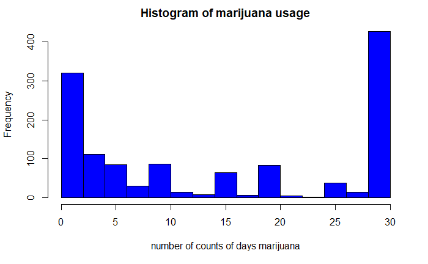

```r
hist(BRFSS.CO$MARIJANA, xlab="number of counts of days marijuana", ylab="Frequency",main="Histogram of marijuana usage",col="blue")
```

- 2. Display histograms of the number of counts of days marijuana or hasish was used in the last 30 days by sex, employed category, income category, and age category (hint use `facet_grid`)

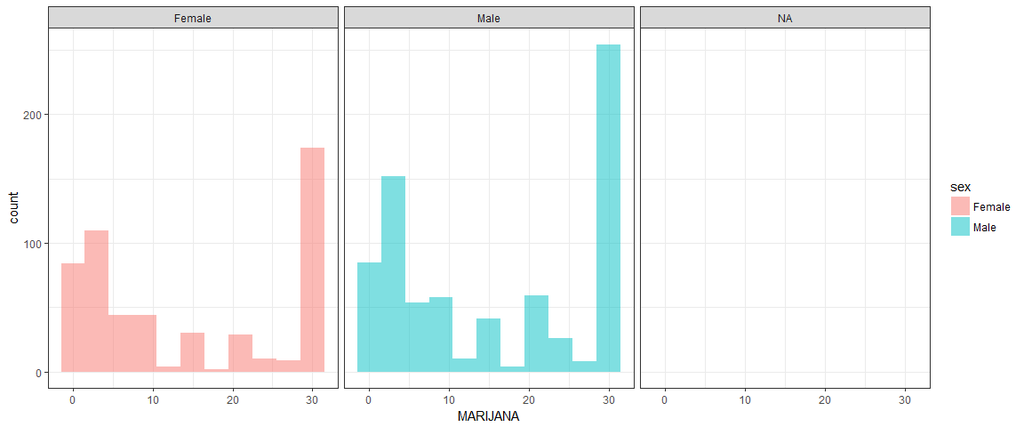

```r
# Histograms of the number of counts of days marijuana or hasish by sex
ggplot(BRFSS.CO,aes(x=MARIJANA,group=sex,fill=sex))+
  geom_histogram(position="identity",alpha=0.5,binwidth=3)+theme_bw()+facet_grid(~sex)
```

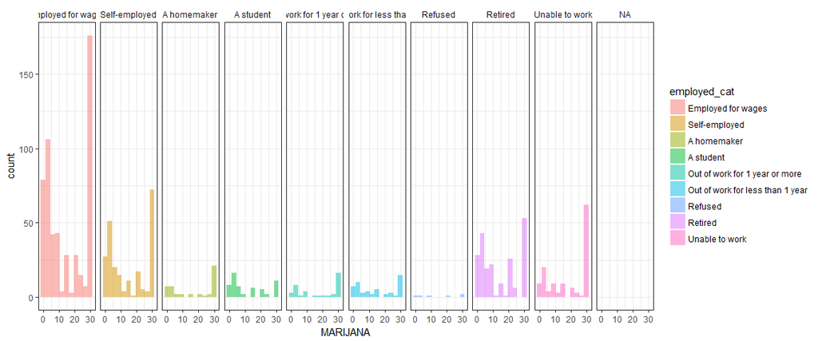

```r
# Histograms of the number of counts of days marijuana or hasish by employement groups
ggplot(BRFSS.CO,aes(x=MARIJANA,group=employed_cat,fill=employed_cat))+
  geom_histogram(position="identity",alpha=0.5,binwidth=3)+theme_bw()+facet_grid(~employed_cat)+
 theme(strip.background = element_blank())
```

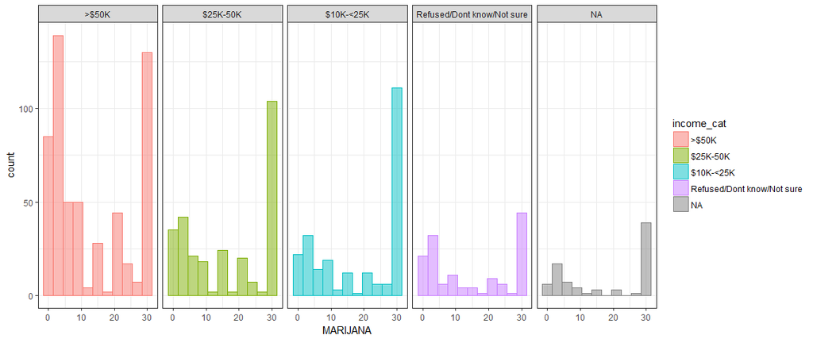

```r
# Histograms of the number of counts of days marijuana or hasish by income groups
ggplot(BRFSS.CO,aes(x=MARIJANA,fill=income_cat,color=income_cat))+
  geom_histogram(position="identity",alpha=0.5,binwidth=3)+theme_bw()+facet_grid(~income_cat)
```

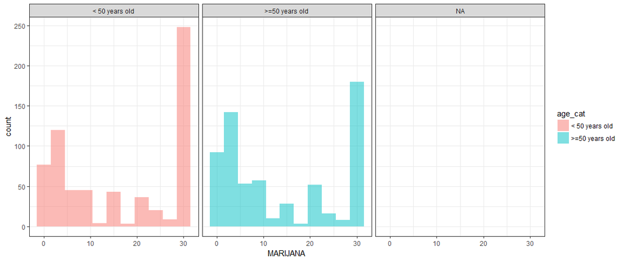

```r
# Histograms of the number of counts of days marijuana or hasish by age groups
ggplot(BRFSS.CO,aes(x=MARIJANA,group=age_cat,fill=age_cat))+
  geom_histogram(position="identity",alpha=0.5,binwidth=3)+theme_bw()+facet_grid(~age_cat)
```

# 3. Poisson regression

Run a Poisson regression model for age category, sex, income category, and employed category as predictors and Marijana/hashish use as the dependent variable (remember the predictors as factor variables).

```r
mod_poisson<- glm(MARIJANA ~ sex + age_cat + income_cat + employed_cat, family="poisson", data=BRFSS.CO)
summary(mod_poisson)
```

```
Call:
glm(formula = MARIJANA ~ sex + age_cat + income_cat + employed_cat,
    family = "poisson", data = BRFSS.CO)

Deviance Residuals:
    Min       1Q   Median       3Q      Max
-6.0177  -3.6779  -0.4741   2.5506   5.2818

Coefficients:
                                              Estimate Std. Error z value Pr(>|z|)
(Intercept)                                   2.569609   0.018306 140.368  < 2e-16 ***
sexMale                                       0.103684   0.015635   6.631 3.32e-11 ***
age_cat>=50 years old                        -0.228715   0.018069 -12.658  < 2e-16 ***
income_cat$25K-50K                            0.245509   0.019143  12.825  < 2e-16 ***
income_cat$10K-<25K                           0.358810   0.020336  17.644  < 2e-16 ***
income_catRefused/Dont know/Not sure          0.144664   0.025836   5.599 2.15e-08 ***
employed_catSelf-employed                     0.037570   0.021306   1.763   0.0778 .
employed_catA homemaker                       0.230719   0.038420   6.005 1.91e-09 ***
employed_catA student                        -0.310494   0.043407  -7.153 8.49e-13 ***
employed_catOut of work for 1 year or more    0.201417   0.047522   4.238 2.25e-05 ***
employed_catOut of work for less than 1 year -0.087245   0.040400  -2.160   0.0308 *
employed_catRefused                           0.009799   0.105733   0.093   0.9262
employed_catRetired                           0.064766   0.025981   2.493   0.0127 *
employed_catUnable to work                    0.193618   0.028592   6.772 1.27e-11 ***
---
Signif. codes:  0 *** 0.001 ** 0.01 * 0.05 . 0.1   1

(Dispersion parameter for poisson family taken to be 1)

    Null deviance: 13509  on 1209  degrees of freedom
Residual deviance: 12709  on 1196  degrees of freedom
  (13686 observations deleted due to missingness)
AIC: 17593

Number of Fisher Scoring iterations: 5
```

# 4. Negative Binomial regression

Run a Negative Binomial regression model for sex, income category, and employed category as predictors and Marijana/hashish use as the dependent variable.

```r
mod_NB<- glm.nb(MARIJANA ~ sex + age_cat + income_cat + employed_cat, data=BRFSS.CO)
summary(mod_NB)
```

```
Call:
glm.nb(formula = MARIJANA ~ sex + age_cat + income_cat + employed_cat,
    data = BRFSS.CO, init.theta = 1.166654904, link = log)

Deviance Residuals:
    Min       1Q   Median       3Q      Max
-2.0105  -1.2980  -0.1402   0.5923   1.4789

Coefficients:
                                             Estimate Std. Error z value Pr(>|z|)
(Intercept)                                   2.55719    0.06635  38.541  < 2e-16 ***
sexMale                                       0.11810    0.05769   2.047 0.040643 *
age_cat>=50 years old                        -0.23304    0.06637  -3.511 0.000446 ***
income_cat$25K-50K                            0.25125    0.07157   3.510 0.000447 ***
income_cat$10K-<25K                           0.37089    0.07913   4.687 2.77e-06 ***
income_catRefused/Dont know/Not sure          0.14312    0.09455   1.514 0.130122
employed_catSelf-employed                     0.04375    0.07908   0.553 0.580069
employed_catA homemaker                       0.26190    0.15266   1.716 0.086242 .
employed_catA student                        -0.31214    0.14731  -2.119 0.034097 *
employed_catOut of work for 1 year or more    0.16295    0.19459   0.837 0.402347
employed_catOut of work for less than 1 year -0.07438    0.14984  -0.496 0.619629
employed_catRefused                           0.01995    0.39593   0.050 0.959807
employed_catRetired                           0.06152    0.09292   0.662 0.507922
employed_catUnable to work                    0.19954    0.11414   1.748 0.080420 .
---
Signif. codes:  0 *** 0.001 ** 0.01 * 0.05 . 0.1   1

(Dispersion parameter for Negative Binomial(1.1667) family taken to be 1)

    Null deviance: 1390.0  on 1209  degrees of freedom
Residual deviance: 1330.8  on 1196  degrees of freedom
  (13686 observations deleted due to missingness)
AIC: 9029.2

Number of Fisher Scoring iterations: 1

              Theta:  1.1667
          Std. Err.:  0.0492

 2 x log-likelihood:  -8999.1610
```

# 5.

Compare models using the likelihood ratio test. Which model is better and on what basis do you make that conclusion?

```r
##Compare models using likelihood ratio test
lrtest(mod_poisson, mod_NB)
```

```
Likelihood ratio test

Model 1: MARIJANA ~ sex + age_cat + income_cat + employed_cat
Model 2: MARIJANA ~ sex + age_cat + income_cat + employed_cat
  #Df  LogLik Df  Chisq Pr(>Chisq)
1  14 -8782.7
2  15 -4499.6  1 8566.3  < 2.2e-16 ***
---
Signif. codes:  0 *** 0.001 ** 0.01 * 0.05 . 0.1   1
```

The highly significant p-value means that the negbin regression is better than the Poisson regression, we should accept the negbin results other than the Poisson regression.

# 6. Model comparison

As the results show, the Poisson regression estimates SEs that are always smaller (as shown by the narrower CIs) than those from the negbin. This implies that the Poisson regression leads to biased significance tests, and tends to make non-significant predictors significant.

```r
library(stargazer)
stargazer(mod_poisson, mod_NB, title="Model comparison - Poisson model vs Negative Binomial model ",
          ci=TRUE,type="text",align=TRUE,single.row=TRUE)
```

[output not shown]

[output not shown]

# 7.

Compute robust standard errors and calculate incidence rate ratios and 95% CIs using the robust standard errors

```r
#Compute robust standard errors
robust<-coeftest(mod_NB, vcov = sandwich)
robust
```

```
z test of coefficients:

                                              Estimate Std. Error z value  Pr(>|z|)
(Intercept)                                   2.557194   0.058789 43.4982 < 2.2e-16 ***
sexMale                                       0.118105   0.049856  2.3689   0.01784 *
age_cat>=50 years old                        -0.233039   0.057416 -4.0588 4.933e-05 ***
income_cat$25K-50K                            0.251254   0.059185  4.2452 2.184e-05 ***
income_cat$10K-<25K                           0.370890   0.060819  6.0983 1.072e-09 ***
income_catRefused/Dont know/Not sure          0.143118   0.082009  1.7451   0.08096 .
employed_catSelf-employed                     0.043752   0.068105  0.6424   0.52060
employed_catA homemaker                       0.261899   0.119535  2.1910   0.02845 *
employed_catA student                        -0.312144   0.140612 -2.2199   0.02643 *
employed_catOut of work for 1 year or more    0.162955   0.133017  1.2251   0.22055
employed_catOut of work for less than 1 year -0.074377   0.123245 -0.6035   0.54618
employed_catRefused                           0.019953   0.336055  0.0594   0.95265
employed_catRetired                           0.061518   0.081515  0.7547   0.45044
employed_catUnable to work                    0.199542   0.083294  2.3956   0.01659 *
---
Signif. codes:  0 *** 0.001 ** 0.01 * 0.05 . 0.1   1
```

```r
##incidence rate ratios and 95% CIs using the robust standard errors
est <- cbind(IRR = coef(mod_NB), "2.5%"=robust[,1]-1.96*robust[,2], "97.5%"=robust[,1]+1.96*robust[,2])
exp(est)
```

```
                                                    IRR       2.5%      97.5%
(Intercept)                                  12.8995694 11.4956470 14.4749478
sexMale                                       1.1253622  1.0205966  1.2408820
age_cat>=50 years old                         0.7921229  0.7078135  0.8864746
income_cat$25K-50K                            1.2856361  1.1448235  1.4437685
income_cat$10K-<25K                           1.4490236  1.2861905  1.6324716
income_catRefused/Dont know/Not sure          1.1538659  0.9825342  1.3550739
employed_catSelf-employed                     1.0447234  0.9141750  1.1939147
employed_catA homemaker                       1.2993951  1.0279946  1.6424480
employed_catA student                         0.7318758  0.5555792  0.9641150
employed_catOut of work for 1 year or more    1.1769832  0.9068680  1.5275536
employed_catOut of work for less than 1 year  0.9283219  0.7291060  1.1819703
employed_catRefused                           1.0201536  0.5279703  1.9711590
employed_catRetired                           1.0634498  0.9064216  1.2476816
employed_catUnable to work                    1.2208432  1.0369513  1.4373463
```

# 8.

Interpret the incidence rate ratio results for age category, sex, education category, and income category. Does the incidence rate of marijuana and hashish use in the last 30 days vary by the levels of these factors?

- For a categorical variable (`sex`):
- - Being a male increases the expected number of marijuana use by 1.12 times compared to a female, holding other variables constant.
- For a categorical variable (`age_cat`):
- - Being older than 50 years old has 0.80 times of expected number of marijuana use compared to a person younger than 50 years old with other variables constant.
- For a categorical variable (`income_cat`):
- - A person with income between $25K and $50K has 1.28 times of expected number of marijuana use compared to a person with income more than $50K.
- - A person with income between $10K and less than 25K has 1.44 times of expected number of marijuana use compared to a person with income more than $50K.
- For a categorical variable (`employed_cat`):
- - A homemaker has 1.30 times of expected number of marijuana use comapared to a person employed for wages.
- - A student has 0.73 times of expected number of marijuana use compared to a person employed for wages.
- - A person unable to work has 1.22 times of expected number of marijuana use compared to a person employed for wages.

```r
mu <- predict(mod_poisson, type = "response") # predict expected mean count
exp <- sum(dpois(x = 0, lambda = mu)) # sum the probabilities of a 0 count for each mean
round(exp) # predicted number of 0's
```

```
[1] 0
```

```r
sum(BRFSS.CO$MARIJANA < 1) # observed number of 0's
```

```
[1] NA
```

```r
mu <- predict(mod_NB, type = "response") # predict expected mean count
exp <- sum(dpois(x = 0, lambda = mu)) # sum the probabilities of a 0 count for each mean
round(exp) # predicted number of 0's
```

```
[1] 0
```

```r
sum(BRFSS.CO$MARIJANA < 1) # observed number of 0's
```

```
[1] NA
```